# Topic 6 Exercises: Selecting Model Terms

## Question 6.8.1

1. The best subset selection with k predicators will have the smallest training RSS because it’ll choose a model that has the smallest training RSS with k prediactors whereas the forward step-wise and backward step-wise models would choose models that have the smallest training RSS at certain k’s only.
2. The model with k predicators that will have the smallest test RSS is probably the backward-selection model because it’s less inflexible than the other two models.
1. True
2. True
3. False
4. False
5. False

## Question 6.8.2

1. 3. is correct because a lasso model is less flexibile which helps lower the chance of overfitting and lowering the variance. So it’ll give a better predication when its increase in bais is less than the decrease in variance.
2. 3. is correct because similar to the lasso model, a ridge regression model is more restrictive which also lowers the chance of overfitting and the variance so it will give a better predication.
3. 2. is correct because non-linear methods are more flexible than least squares so they’ll give a better predication when their increase in variance is less than their decrease in bias.

## Question 6.8.9

```r
library(ISLR)
data(College)
set.seed(1)
train = sample(1:dim(College)[1], dim(College)[1] / 2)
test <- -train
College.train <- College[train, ]
College.test <- College[test, ]
```

```r
mod <- lm(Apps~., data=College.train)
mod1 <- predict(mod, College.test)
mean((mod1 - College.test$Apps)^2)
```

```
## [1] 1108531
```

The test error is 1108531.

```r
library(glmnet)
ridgetrain <- model.matrix(Apps ~ ., data= College.train)

ridgetest <- model.matrix(Apps ~ ., data = College.test)

grid <- 10^seq(4,-2,length= 100)

ridgemod <- glmnet(ridgetrain, College.train$Apps, alpha = 0, lambda = grid, thresh = 1e-12)

cvmod <- cv.glmnet(ridgetrain, College.train$Apps, alpha = 0, lambda = grid, thresh = 1e-12)

lamridge <- cvmod$lambda.min
lamridge
```

```
## [1] 0.01149757
```

```r
predridge <- predict(ridgemod, s = lamridge, newx = ridgetest)

mean((predridge - College.test$Apps)^2)
```

```
## [1] 1108512
```

The test error is 1108512, which is a little bit better than least squares.

```r
lassomod <- glmnet(ridgetrain, College.train$Apps, alpha = 1, lambda = grid, thresh = 1e-12)

lassocv <- cv.glmnet (ridgetrain, College.train$Apps, alpha = 1, lambda = grid, thresh = 1e-12)

lassolam <- lassocv$lambda.min
lassolam
```

```
## [1] 28.48036
```

```r
predlasso <- predict (lassomod, s= lassolam, newx = ridgetest)

mean((predlasso - College.test$Apps)^2)
```

```
## [1] 1028718
```

```r
predict(lassomod, s = lassolam, type = "coefficients")
```

```
## 19 x 1 sparse Matrix of class "dgCMatrix"
##                         1
## (Intercept) -4.248125e+02
## (Intercept)  .
## PrivateYes  -4.955003e+02
## Accept       1.540306e+00
## Enroll      -3.900157e-01
## Top10perc    4.779689e+01
## Top25perc   -7.926581e+00
## F.Undergrad -9.846932e-03
## P.Undergrad  .
## Outstate    -5.231286e-02
## Room.Board   1.880308e-01
## Books        1.265938e-03
## Personal     .
## PhD         -4.137294e+00
## Terminal    -3.184316e+00
## S.F.Ratio    .
## perc.alumni -2.181304e+00
## Expend       3.193679e-02
## Grad.Rate    2.877667e+00
```

```r
library(pls)
```

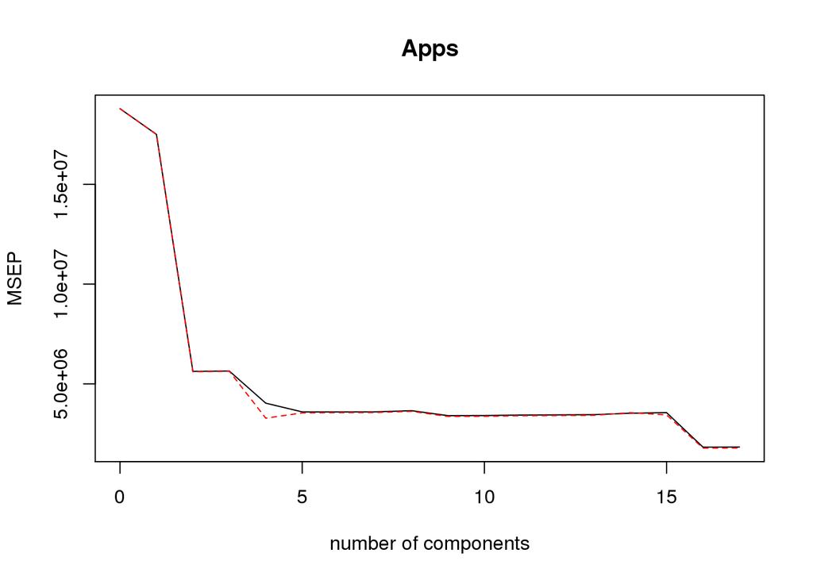

```r
pcrmod <- pcr(Apps ~ ., data= College.train, scale = TRUE, validation = "CV")

validationplot(pcrmod, val.type = "MSEP")
```

```r
predpcr <- predict(pcrmod, College.test, ncomp = 10)

mean((predpcr - College.test$Apps)^2)
```

```
## [1] 1505718
```

The test error is 1505718 which is higher than least squares.

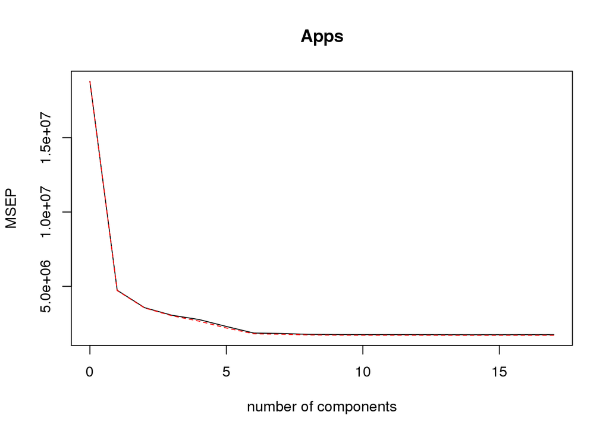

```r
plsmod <- plsr(Apps ~ ., data=College.train, scale = TRUE, validation = "CV")

validationplot(plsmod, val.type = "MSEP")
```

```r
predpls <- predict(plsmod, College.test, ncomp = 10)

mean((predpls - College.test$Apps)^2)
```

```
## [1] 1134531
```

The test error is 1134531 which is higher than least squares.

```r
test.avg <- mean(College.test$Apps)

lmr2 <- 1 - mean((mod1 - College.test$Apps)^2) / mean((test.avg - College.test$Apps)^2)

lmr2
```

```
## [1] 0.9010682
```

```r
ridger2 <- 1 - mean((predridge - College.test$Apps)^2) / mean((test.avg - College.test$Apps)^2)

ridger2
```

```
## [1] 0.90107
```

```r
lassor2 <- 1 - mean((predlasso - College.test$Apps)^2) / mean((test.avg - College.test$Apps)^2)

lassor2
```

```
## [1] 0.9081912
```

```r
pcrr2 <- 1 - mean((predpcr - College.test$Apps)^2) / mean((test.avg - College.test$Apps)^2)

pcrr2
```

```
## [1] 0.865621
```

```r
plsr2 <- 1 - mean((predpls - College.test$Apps)^2) / mean((test.avg - College.test$Apps)^2)

plsr2
```

```
## [1] 0.8987478
```